# R Notebook

```r
library(tidyverse)
library(ggplot2)
library(readxl)
```

’Kronos Summary Report (By Task)_Q1903_20230205.xlsx’ ’Kronos Summary Report (By Task)_Q1903_20230130.xlsx’

Home Project Home Task Transfer Project Transfer Task Activity Name Activity Description Department Fermi ID Last Name First Name Timecard Start Timecard End Transaction Date Job Functional Code Hours Expenditure Type He Indicator Historical Date Project Charge Task Code DSC WBS Name Full Name WBS Timecard End : Month Timecard End: Year Units Task Name Long Task Name Description Function Role Function Category

Columns 1, 2, and 18 need to be forced to text type there are a total of 32 columns

```r
chg.cols = rep('guess',32)
chg.cols[1]='text'
chg.cols[2]='text'
chg.cols[18]='text'

c1 <- read_excel('../../Kronos Summary Report (By Task)_Q1903_20230205.xlsx', col_types=chg.cols)
c2 <- read_excel('../../Kronos Summary Report (By Task)_Q1903_20230130.xlsx', col_types=chg.cols)
all.charges <- bind_rows(c1,c2)
names(all.charges) <- make.names(colnames(all.charges))
```

Budget spreadsheet ‘MAGIS FY23 Budget for cuts v8.xlsx’

Task Name and Notes contain the task code names that we need. Each of the important Notes starts with Q, and we then want up to semi-colon.

```r
all.budget <- read_excel('../../MAGIS FY23 Budget for cuts v8.xlsx', sheet='Data Entry', skip=1)
names(all.budget) <- make.names(colnames(all.budget))
```

Pull out year and month from timecard start dates Add these columns to the charges dataframe

```r
tmp<-as.POSIXlt(all.charges$Timecard.Start)
all.charges <- all.charges %>% mutate(year=tmp$year-100+2000,month=tmp$mon)
```

unlist(as.POSIXlt(all.charges$Timecard.End[5001])) sec min hour mday mon year wday yday isdst 0 0 0 22 4 122 0 141 0

What I really want are two new columns for each row: Year, Month then group_by Task.Name, Year, Month, summarizing Hours

This is accumulated hours by task name and year.

```r
hours.by.task <- all.charges %>% group_by(Task.Name, year, month) %>% summarise(Hours=sum(Hours))
hours.by.task <- hours.by.task %>% group_by(Task.Name, year) %>% mutate(cs=cumsum(Hours))

hours.by.cat <- all.charges %>% group_by(Function.Category, year, month) %>% summarise(Hours=sum(Hours))
hours.by.cat <- hours.by.cat %>% group_by(Function.Category, year) %>% mutate(cs=cumsum(Hours))

hours.task.total <- all.charges %>% group_by(Task.Name,year) %>% summarise(Hours=sum(Hours))
hours.cat.total <- all.charges %>% group_by(Function.Category,year) %>% summarise(Hours=sum(Hours))
```

```r
hours.task.plot <- ggplot(hours.by.task, aes(month,cs)) + geom_point()
hours.cat.plot <- ggplot(hours.by.cat, aes(month,cs)) + geom_point()

hours.task.plot <- hours.task.plot  + facet_grid(vars(Task.Name),vars(year))
hours.cat.plot <- hours.cat.plot  + facet_grid(vars(Function.Category),vars(year))
```

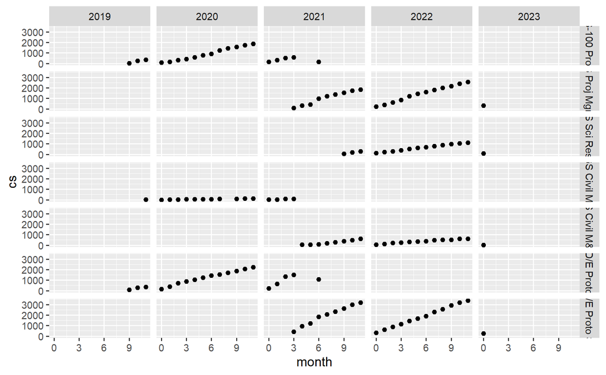

```r
print(hours.task.plot)
```

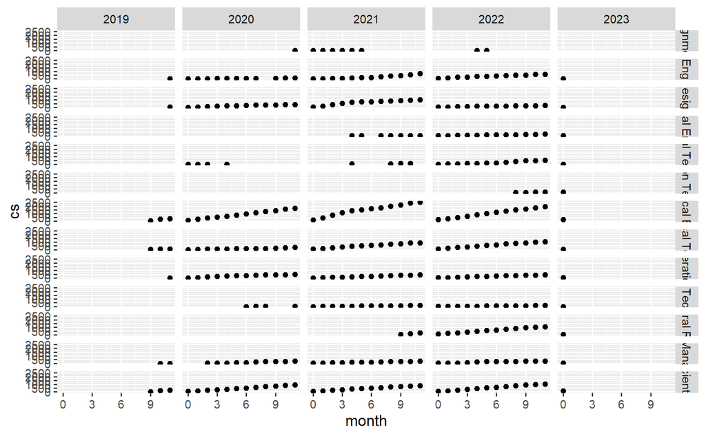

```r
print(hours.cat.plot)
ggsave(hours.task.plot, filename="hoursbyyearbytask.pdf",units="in", height=10, device="pdf")
ggsave(hours.cat.plot, filename="hoursbyyearbyfunction.pdf",units="in", height=10, device="pdf")
```

```r
print(hours.task.total)
```

| Task.Name | year | Hours |
| --- | --- | --- |
| MAGIS Proj Mgmt-QIS | 2021 | 1850.50 |
| MAGIS Proj Mgmt-QIS | 2022 | 2549.62 |
| MAGIS Proj Mgmt-QIS | 2023 | 331.50 |
| MAGIS Sci Research | 2021 | 272.00 |
| MAGIS Sci Research | 2022 | 1105.90 |
| MAGIS Sci Research | 2023 | 81.60 |
| MAGIS-100 Proj Mgmt | 2019 | 338.00 |
| MAGIS-100 Proj Mgmt | 2020 | 1864.30 |
| MAGIS-100 Proj Mgmt | 2021 | 137.50 |
| MGS Civil M&S | 2019 | 7.00 |

[output cut: 11 more lines]

```r
print(hours.cat.total)
```

| Function.Category | year | Hours |
| --- | --- | --- |
| Alignment | 2020 | 2.00 |
| Alignment | 2021 | 11.00 |
| Alignment | 2022 | 18.00 |
| Civil Engineer | 2019 | 7.00 |
| Civil Engineer | 2020 | 123.00 |
| Civil Engineer | 2021 | 697.00 |
| Civil Engineer | 2022 | 622.50 |
| Civil Engineer | 2023 | 11.00 |
| Design | 2019 | 26.00 |
| Design | 2020 | 382.00 |

[output cut: 44 more lines]